# Estatistica experimental

27 junho, 2022

## Delineamento

## Delineamento Inteiramente Casualizado (DIC)

**Delineamento** é o controle do pesquisador sobre o experimento. Quando um local é homogêneo, não é necessário controlar onde serão colocadas as repetições e tratamentos, esses, podem *apenas* serem distribuidos aleatóriamento no local. Isso é im DIC.

O modelo para determinar o valor de cada observação é:

\[ Y_{ij}=\mu+T_j+\varepsilon_{ij} \]

\[ \varepsilon \sim N(0, I\sigma^2) \]

Sua resposta (\(Y\)), na repetição \(i\) do nível \(j\) do tratamento, é igual a média geral (\(\mu\)), somado ao efeito do tratamento e ao erro (os quais devem ser normais). Já o efeito do tratamento (\(T_j\)) é a diferença entre a média geral e a média de cada um dos níveis: \(\mu-T_j\).

Se quisermos estimar apenas a média:

\[ \mu_{j}=\mu+T_j \]

A média (\(\mu\)) no nível \(j\) do seu tratamento é igual a média geral somada ao efeito do tratamento.

## Exemplo

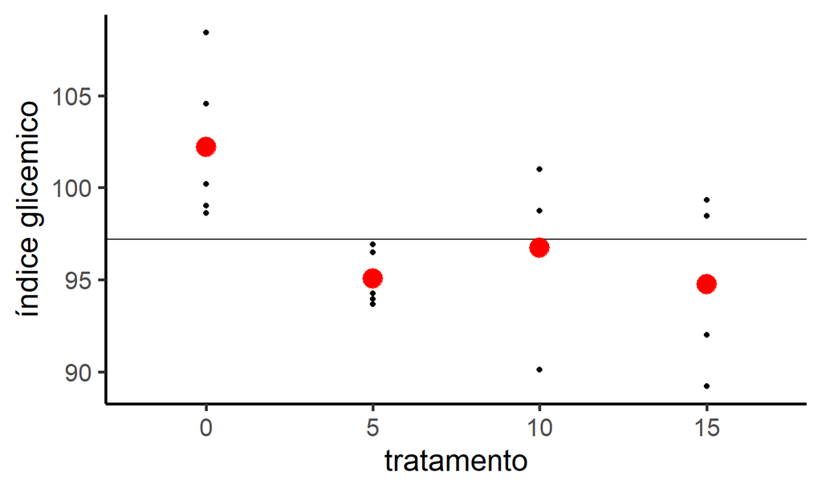

A média geral (linha horizontal) é: \(97.2\), esse é nosso \(\mu\). Já a média **por** tratamento (ponto vermelho), é: dose 0 = \(102.2\); dose 5 = \(95.1\); dose 10 = \(96.7\); dose 15 = \(94.7\).

Repare que dependendo do tratamento, a média dele é maior ou menor que nossa média geral, o quanto maior ou menor é o nosso **efeito do tratamento**. Por exemplo: o efeito da dose 0 é aumentar \(5\) unidades da média geral (\(97.2 - 102.2\)).

## Exemplo no R - DIC fatorial simples

Ao invés do R utilizar a formula para estimar a média \(\mu_j=\mu+T_j\). O R utiliza ela de forma simplificada, sem a média geral: \(\mu_j=T_j\).

Dessa maneira, é usado o primeiro nível como base o efeito dos demais níveis são somados a ele.

### \(1^{\circ}\) Carregando os dados

```r
library(ExpDes.pt) # carregar o pacote que tem os dados de exemplo (ex1)
dados <- ex1 # carregar ex1 armazenar em "dados"
dados$trat <- as.factor(dados$trat) # Entender que "trat" é um fator e não números
head(dados) # mostrar só o começo (head) dados
```

```
##   trat     ig
## 1    0 108.43
## 2    0 102.36
## 3    0 104.55
## 4    0  98.63
## 5    0  99.02
## 6    0 100.20
```

## Exemplo no R - DIC fatorial simples

### \(2^{\circ}\) Criando o modelo

\[ lm(formula, data,...) \]

**lm()** significa *linear models* e nela podemos inserir a fórmula do DIC: **Resposta~Tratamento** (\(\mu_j=T_j\)).

```r
lm(ig~trat, data = dados)
```

```
##
## Call:
## lm(formula = ig ~ trat, data = dados)
##
## Coefficients:
## (Intercept)        trat5       trat10       trat15
##     102.198       -7.140       -5.455       -7.455
```

Repare, \(102.198\) (“intercept”) é a média da dose 0, ele foi utilizado como “base”, trat5 é a diferença entre a média da dose 0 e a média da dose 5, ou seja, \(95.058 - 102.198 = -7.140\).

## DIC fatorial duplo

Quando temos mais tratamentos na nossa pesquisa, devemos inserir não só o efeito desses tratamentos, mas também o efeito da interação:

\[ \mu_{jh}=\mu+T_j+T_h+T_J*T_h \] A média (\(\mu\)) no nível \(j\) do seu primeiro tratamento e no nível \(h\) do seu segundo tratamento é igual a média geral somada aos **efeitos simples** dos tratamentos, assim como o **efeito da interação** deles.

## Exemplo no R - DIC fatorial duplo

### \(1^{\circ}\) Carregando os dados

Experimento em campo para testar a compostagem de casca de café misturada ou não com esterco bovinos (variável esterco) em diferentes intervalos de revolvimento (variável revol).

```r
library(ExpDes.pt) # carregar o pacote que tem os dados de exemplo (ex4)
dados <- ex4 # armazenar ex4 em "dados"
dados$revol <- as.factor(dados$revol) # entender que "trat" é um fator e não números
dados # mostrar os dados
```

```
##    revol esterco rep  c    n    k    p  zn     b    ca    cn
## 1      5     com   1 18 1.28 4.80 3.68 109  5.31 12.01 14.06
## 2      5     com   2 15 1.31 4.65 3.71 125  5.97  8.62 11.45
## 3      5     com   3 26 1.74 4.13 3.71 119  5.86  8.69 14.94
## 4     10     com   1 17 1.70 4.50 3.71 126  5.86 10.62 10.00
## 5     10     com   2 23 1.49 2.55 3.83 119  6.07  8.18 15.44
## 6     10     com   3 20 1.42 4.50 3.54 110  4.88  8.47 14.08
## 7     15     com   1 26 1.48 4.88 3.71 113  3.69  8.07 17.57
## 8     15     com   2 16 1.53 7.50 3.71 107  4.66  7.77 10.46
## 9     15     com   3 21 1.47 6.00 3.71 102  4.45  7.77 14.29
## 10    20     com   1 27 1.95 4.65 3.88 111  5.64 10.94 13.85
## 11    20     com   2 22 1.57 5.55 4.00 120  4.88  8.59 14.01
## 12    20     com   3 21 2.28 6.60 4.31 126  6.29  9.66  9.21
## 13     5     sem   1 33 1.86 1.65 2.12  36 10.09  7.51 17.74
## 14     5     sem   2 30 1.72 7.80 2.64  65  9.11  8.29 17.44
## 15     5     sem   3 18 2.26 6.23 3.14  75  7.92 12.27  7.96
## 16    10     sem   1 27 1.41 5.85 2.24  56 11.94  7.12 19.15
## 17    10     sem   2 18 0.96 5.33 2.29  61  8.14  8.17 18.75
## 18    10     sem   3 20 1.90 4.13 2.68  69  4.01  4.94 10.53
## 19    15     sem   1 29 1.36 5.10 2.65  61  9.33 12.53 21.32
## 20    15     sem   2 22 1.42 4.88 2.38  64 18.56  6.28 15.49
## 21    15     sem   3 31 1.80 5.40 2.79  64 18.56  6.65 17.22
## 22    20     sem   1 37 2.16 5.33 2.10  42 27.46  7.21 17.13
## 23    20     sem   2 34 1.70 4.13 2.25  64  8.35  7.54 20.00
## 24    20     sem   3 33 2.23 4.88 1.56  30 10.74  7.19 14.80
```

## Exemplo no R - DIC fatorial duplo

### \(2^{\circ}\) Criando o modelo:

No R, a notação é **Resposta~Tratamento1+Tratamento2+Tratamento1**\(\colon\)**Tratamento2** ou por sua forma abreviada: **Resposta~Tratamento1*Tratamento2**.

```r
lm(c~revol*esterco, data=dados)
```

```
##
## Call:
## lm(formula = c ~ revol * esterco, data = dados)
##
## Coefficients:
##        (Intercept)             revol10             revol15             revol20
##            19.6667              0.3333              1.3333              3.6667
##         estercosem  revol10:estercosem  revol15:estercosem  revol20:estercosem
##             7.3333             -5.6667             -1.0000              4.0000
```

Repare que no fatorial duplo, foi utilizada a média da resposta no intervalo de revolvimento 5 (primeiro nível do tratamento 1) com a presença de esterco (primeiro nível do tratamento 2). É o valor 19.6667 indicado no “intercept” e os demais valores são a diferença em relação ao “intercept”.

## Demais fatoriais

Para um fatorial triplo ou qualquer que seja a quantidade de tratamentos que possui, basta utilizar a mesma notação anterior, apenas acrescentando “*” e o novo tratamento:

\[ Resposta\sim Tratamento1*Tratamento2*Tratamento3… \]

## Delineamento em Blocos Casualizados (DBC)

Nesse delineamento é feito o controle da área experimental, pois, essa é heterogênea. Então subdivide-se essa área em blocos, os quais são homogeneos dentro deles, então podemos distribuir nossos tratamentos em cada bloco:\[ \mu_{ij}=\mu+bloco_i+T_j \]

Ou seja, a média de um dos níveis (\(j\)) do seu tratamento, em um dos blocos (\(i\)), vai ser igual à média geral (\(\mu\)) somado aos efeitos do tratamento (\(T_j\)) e do bloco.

## Exemplo no R - DBC Fatorial simples

### \(1^{\circ}\) Carregando os dados

Dados do livro Pimentel-Gomes da produção (\(t. ha^{-1}\)) de oito variedades de batatinha em DBC (quatro blocos).

```r
# lendo dados do repositório online
dados <- dget("https://raw.githubusercontent.com/thomasbrunomichelon/data/main/Pimentel%20gomes%20DBC")
dados
```

```
##    bloco   variedade producao
## 1      I    B 116-51     23.1
## 2      I      B 1-52     20.0
## 3      I   B 25-50 E     12.7
## 4      I   B 72-53 A     18.0
## 5      I Buena Vista     15.4
## 6      I     Huinkul     21.1
## 7      I    Kennebec      9.2
## 8      I S. Rafalela     22.6
## 9     II    B 116-51     24.2
## 10    II      B 1-52     21.1
## 11    II   B 25-50 E     18.0
## 12    II   B 72-53 A     24.6
## 13    II Buena Vista     11.9
## 14    II     Huinkul     27.0
```

[output cut: 18 more lines]

## Exemplo no R - DBC Fatorial simples

### \(2^{\circ}\) Criando modelo

A notação do DBC é: **Resposta~Bloco+Tratamento**.

```r
lm(producao~bloco+variedade, data=dados)
```

```
##
## Call:
## lm(formula = producao ~ bloco + variedade, data = dados)
##
## Coefficients:
##          (Intercept)               blocoII              blocoIII
##               20.325                 3.500                 2.275
##              blocoIV     variedadeB 116-51    variedadeB 25-50 E
##                2.025                 0.225                -5.775
##   variedadeB 72-53 A  variedadeBuena Vista      variedadeHuinkul
##                0.525                -9.850                 2.775
##    variedadeKennebec  variedadeS. Rafalela
##              -11.575                 3.175
```

## Demais delineamentos

Para os demais delineamentos, basta saber qual é o modelo e inserí-lo na função **lm()**:

- Quadrado latino: **Resposta~linha+coluna+tratamento**
- Tratamento adicional: **Resposta~Tratamento adicional+Tratamento***
  - Para o tratamento adicional, é necessário criar uma nova variável e atribuir um valor para o tratamento adicional e outro valor para os demais tratamentos. Ex.: uma coluna com “a” para o tratamento adicional e “b” para os demais.

Para delineamentos com efeitos fixos e aleatórios (como no caso de parcelas subdividadas), deve-se utilizar a função **aov()**.

- Parcela subdividida em DIC: **Resposta~Fator1*Fator2+Erro(Fator1:repetição)**
- Parcela subdividida em DBC: **Resposta~Bloco+Fator1*Fator2+Erro(bloco/Fator1)**

## ANOVA

## Porque a ANOVA?

Se quisermos testar um tratamento com dois níveis A e B, basta fazer um teste T para as médias. Porém, se temos um tratamento com mais níveis A, B e C, já teriamos três testes: AB, AC e BC. Quanto mais testes, maior a chance de errarmos, visto que os testes têm uma “probabilidade de acerto”.

Uma alternativa é testar ao invés da média, as variâncias das médias: **variância entre os níveis vs variância dentro de cada nível.**

Assim, independente do número de níveis, estariamos fazendo apenas um teste e testando “todas as médias de uma vez”.

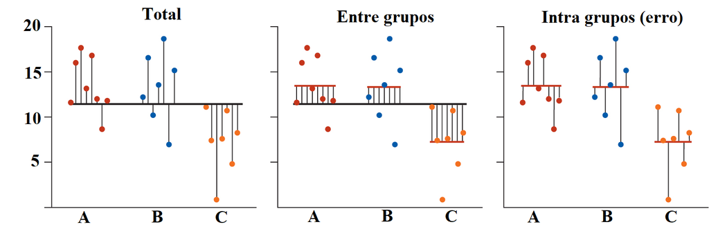

## Pressupostos

Os pressupostos que devemos checar para análise de variância são em relação ao resíduo (ou erros), ou seja, a diferença entre o que foi medido e o estimados pelo modelo.

O erros devem ser:

- Independentes: os erros não devem apresentar correlação entre si.
- Variância homogênea (homocedásticos): os erros devem variar de forma igual.
- Normais: erros com média igual a 0 e variância igual \(\sigma^2\).

## Testes dos pressupostos

Os testes são aplicados aos erros. Dessa forma, devemos primeiro ajustar o modelo, encontrar o erro e aí aplicar os testes:

```r
library(ExpDes.pt)
dados <- ex1
dados$trat <- as.factor(dados$trat)
modelo <- lm(ig~trat, data=dados)
erros <- residuals(modelo) # função "residuals" para obter os erros
```

- Normalidade dos resíduos: teste de Shapiro-Wilk:

  \[ shapiro.test(object,...) \]

```r
shapiro.test(erros)
```

```
##
##  Shapiro-Wilk normality test
##
## data:  erros
## W = 0.9812, p-value = 0.917
```

## Testes dos pressupostos

- Homogeneidade das variâncias dos resíduos: teste de Levene e Bartlett

  \[ leveneTest(object, data,...) \]

```r
library(car) # pacote com a função
leveneTest(erros~trat, data=dados) # Levene
```

```
## Levene's Test for Homogeneity of Variance (center = median)
##       Df F value Pr(>F)
## group  3  0.8811 0.4676
##       20
```

\[ bartlett.test(object, data,...) \]

```r
bartlett.test(erros~trat, data=dados)
```

```
##
##  Bartlett test of homogeneity of variances
##
## data:  erros by trat
## Bartlett's K-squared = 4.8091, df = 3, p-value = 0.1863
```

## Testes dos pressupostos

- Independência dos resíduos: teste de Durbin-Watson

  \[ durbinWatsonTest(model,...) \]

```r
library(car)
durbinWatsonTest(modelo)
```

```
##  lag Autocorrelation D-W Statistic p-value
##    1     -0.06090768      1.910775   0.386
##  Alternative hypothesis: rho != 0
```

## Análise gráfica dos pressupostos

Se usarmos a função **plot()** em um modelo que criamos com a função **lm()**, são gerados quatro gráficos para análise dos resíduos:

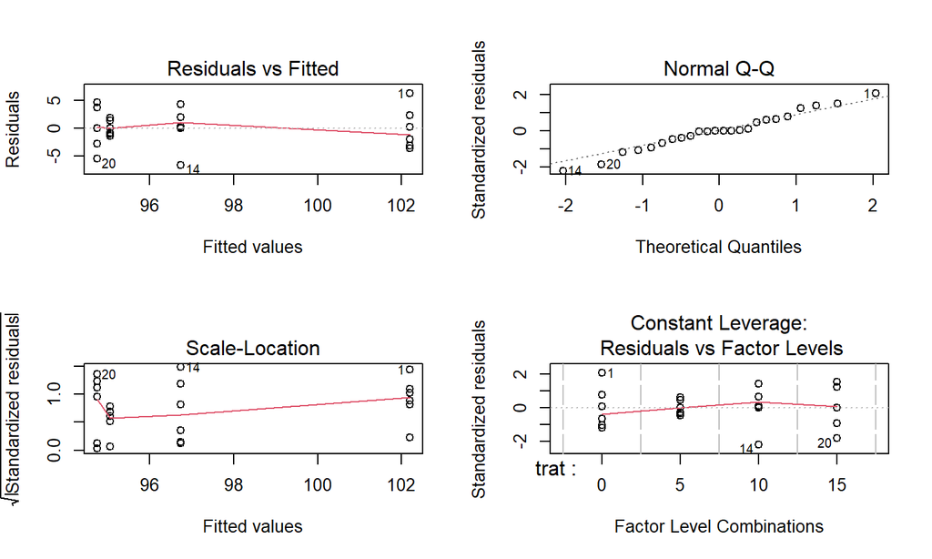

```r
modelo <- lm(ig~trat, data=dados)
par(mfrow=c(2,2))
plot(modelo)
```

## Transformações

Se seus dados não são normais, você pode transformá-los. Existe diversas fórmulas e transformações. Por exemplo, podemos simplesmente elevar nossos dados: \(resposta^2\). Ou realizar o logarítimo: \(log(resposta)\). Então qual transformação utilizar?

## Box-Cox

Box-Cox é um **família** de transformações, ou seja, em sua fórmula, podemos tranformar nossos dados de diferentes formas conforme um critério. O critério é a escolha de uma váriável chamada \(\lambda\).

Quando escolhemos algum valor de \(\lambda \neq 0\), os dados (\(y\)) são transformados conforme a seguinte fórmula:

\[ y'= (y^\lambda-1)/\lambda \]

Quando escolhemos \(\lambda=0\), é feito apenas o \(log(y)\), na base \(e\).

Então basta escolhermos vários valores para lambda, transformar nossos dados e ver qual a melhor transformação.

## Exemplo no R - Box-Cox

### \(1^{\circ}\) Identificando o melhor lambda

Podemos testar vários lambdas e avaliar o ajuste automaticamente pela função do pacote **MASS**:

\[ boxcox(object,...) \]

```r
library(MASS) # carregando o pacote com a função "boxcox"
bc <- boxcox(dados$ig~dados$trat) # testando os lambdas e identificando o melhor
```

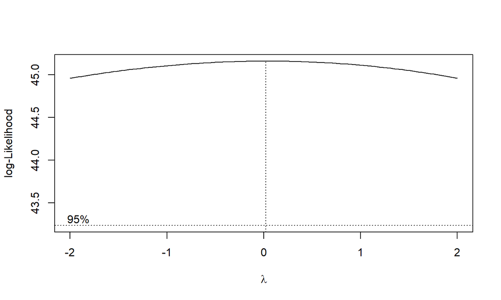

Repare que o maior valor de *log-likelihood* gerado no gráfico é quando \(\lambda\) é quase 0.

## Exemplo no R - Box-Cox

### \(2^{\circ}\) Extraindo o lambda

Vamos ver qual exatamente o valor de lambda:

```r
maior_likelihood <- which.max(bc$y) # maior valor do "log likelihood"
lambda <- bc$x[maior_likelihood] # valor do lambda que corresponde ao maior "log likelihood"
lambda # valor de lambda
```

```
## [1] 0.02020202
```

Nosso lambda é \(0.02\) aproximadamente. Ou seja, nossos dados transformados ficariam: \(y'=y^{0.02}-1/0.02\).

## Exemplo no R - Box-Cox

### \(3^{\circ}\) Transformando todos os dados e usado no modelo

```r
transformacao <- function(y, lambda) {
      if (lambda == 0L) { # se o lambda for igual a 0, log(y)
      log(y)
      } else { # se for diferente de 0, (y^lambda)-1/lambda
      ((y^lambda) - 1) / lambda
      }
  }
dados_transformados <- transformacao(dados$ig, 0.0202) # transformando
head(cbind(dados$ig, dados_transformados)) # mostrando os dados lado a lado (cbind)
```

```
##             dados_transformados
## [1,] 108.43            4.915064
## [2,] 102.36            4.851772
## [3,] 104.55            4.875021
## [4,]  98.63            4.811029
## [5,]  99.02            4.815359
## [6,] 100.20            4.828359
```

```r
lm(dados_transformados~trat, data=dados) # modelo com os dados transformados
```

## ANOVA

\[ anova(object,...) \]

O *object* é o seu modelo obtido pela função **lm()**.

```r
modelo <- lm(ig~trat, data=dados)
anova(modelo)
```

```
## Analysis of Variance Table
##
## Response: ig
##           Df Sum Sq Mean Sq F value   Pr(>F)
## trat       3 214.88  71.626  6.5212 0.002962 **
## Residuals 20 219.67  10.984
## ---
## Signif. codes:  0 '***' 0.001 '**' 0.01 '*' 0.05 '.' 0.1 ' ' 1
```

## Comparações múltiplas

## Pacote Emmeans

O pacote **emmeans()** possibilita obter as médias marginais realizar o teste de comparação de médias:

\[emmeans(object, specs, type, … )\]

O *object* é o seu modelo e *specs* é o argumento responsável pelo desdobramento das médias:

| Número de fatores | simbolo | exemplo |
| --- | --- | --- |
| Um fator |  | specs = ~ tratamento |
| Dois fatores: fator 1 dentro do fator 2 | \[\|\] | specs = ~ tratamento1 \| tratamento2 |
| Dois fatores: todas as combinações | \[*\] | specs = ~ tratamento1 * tratamento2 |

## Exemplo no R - emmeans fatorial duplo em DIC

### \(1^{\circ}\) Carregando dados

```r
library(ExpDes.pt)
dados <- ex4
dados$revol <- as.factor(dados$revol)
dados$esterco <- as.factor(dados$esterco)
```

### \(2^{\circ}\) Criando o modelo

```r
modelo <- lm(c~revol*esterco, data=dados)
```

## Exemplo no R - emmeans fatorial duplo em DIC

### \(3^{\circ}\) Comparando as médias

```r
library(emmeans)
medias <- emmeans(modelo, specs = ~ revol|esterco) # médias
library(multcomp) # facilitar a visualização por meio das "letras"
cld(medias, Letters = LETTERS, reversed = TRUE)
```

```
## esterco = com:
##  revol emmean  SE df lower.CL upper.CL .group
##  20      23.3 2.8 16     17.4     29.3  A
##  15      21.0 2.8 16     15.1     26.9  A
##  10      20.0 2.8 16     14.1     25.9  A
##  5       19.7 2.8 16     13.7     25.6  A
##
## esterco = sem:
##  revol emmean  SE df lower.CL upper.CL .group
##  20      34.7 2.8 16     28.7     40.6  A
##  15      27.3 2.8 16     21.4     33.3  AB
##  5       27.0 2.8 16     21.1     32.9  AB
##  10      21.7 2.8 16     15.7     27.6   B
##
## Confidence level used: 0.95
## P value adjustment: tukey method for comparing a family of 4 estimates
## significance level used: alpha = 0.05
## NOTE: Compact letter displays can be misleading
##       because they show NON-findings rather than findings.
##       Consider using 'pairs()', 'pwpp()', or 'pwpm()' instead.
```

## Pacote Exp.des

O pacote Exp.des, engloba diversos delinementos e realiza os procedimentos automaticamente: ANOVA, testes de pressupostos e comparação de médias.

Basta usar a função conforme o seu delineamento: **dic()**, **dcb()**, **fat2.dic()**, **fat3.dic()**, **fat2.dbc()**, **fat3.dbc()**, entre outras.

\[ dic(trat, resp, quali = TRUE, mcomp = "tukey",...) \]

Em cada função, existem os argumentos básicos utilizados para realizar a análise:

| Argumento | Função |
| --- | --- |
| trat | variável tratamento |
| resp | variável resposta |
| quali | se os tratamentos são (TRUE) ou não (FALSE) qualitativo |
| mcomp | teste de comparação de médias (Tukey, Scott-Knott, Duncan…) |

Consulte o “?Exp.des para” ver todas as funções do pacote e acessar os demais argumentos da função escolhida.

## Exemplo no R - Exp.des DIC Fatorial duplo

```r
library(ExpDes.pt)
fat2.dic(dados$revol, dados$esterco, dados$c, fac.names = c("revol", "esterco"))
```

```
## ------------------------------------------------------------------------
## Legenda:
## FATOR 1:  revol
## FATOR 2:  esterco
## ------------------------------------------------------------------------
##
##
## Quadro da analise de variancia
## ------------------------------------------------------------------------
##               GL     SQ QM      Fc   Pr>Fc
## revol          3 210.33  5  2.9729 0.06303
## esterco        1 266.67  4 11.3074 0.00396
## revol*esterco  3  71.00  3  1.0035 0.41674
## Residuo       16 377.33  2
## Total         23 925.33  1
## ------------------------------------------------------------------------
## CV = 19.96 %
##
## ------------------------------------------------------------------------
## Teste de normalidade dos residuos (Shapiro-Wilk)
## valor-p:  0.620401
## De acordo com o teste de Shapiro-Wilk a 5% de significancia, os residuos podem ser considerados normais.
## ------------------------------------------------------------------------
##
## Interacao nao significativa: analisando os efeitos simples
## ------------------------------------------------------------------------
## revol
## De acordo com o teste F, as medias desse fator sao estatisticamente iguais.
## ------------------------------------------------------------------------
##   Niveis   Medias
## 1     10 20.83333
## 2     15 24.16667
## 3     20 29.00000
## 4      5 23.33333
## ------------------------------------------------------------------------
## esterco
## Teste de Tukey
## ------------------------------------------------------------------------
## Grupos Tratamentos Medias
## a     sem     27.66667
##  b    com     21
## ------------------------------------------------------------------------
```

## Modelos Lineares Generalizados (GLM)

## O que são?

Alguns dados claramente pertencem a outra distribuição que não a normal: dados de contagem (ex., número de plantas daninhas), dados binomiais (ex., germinação ou não germinação).

Porém, diferente do modelo linear, em que a média de dados normais é obtida por uma **combinação linear entre os coeficientes** (\(\mu_i=\beta_1*Nível_1+\beta_2*Nível_2...\)), o mesmo não ocorre quando usamos outra distribuição.

Já que é dificil estimar a média usando coeficientes que não têm uma combinação linear, a solução encontrada foi **transformar a média dessa distribuição** para que os coeficientes sejam lineares:

\[ g(\mu_j)=\beta_1*Nível_1+\beta_2*Nível_2... \]

O \(g\) é chamado de função de ligação e ela varia de acordo com a distribuição escolhida. Assim, esse método é uma *generalização dos modelos lineares*, pois conseguimos um modelo linear a partir de qualquer distribuição pertencente à familia exponencial (ex., normal, gamma, binomial, poisson…). Ex.:

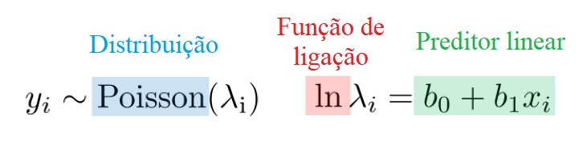

## Por que?

Quando temos dados não normais, o que geralmente é feito:

1. Transformar os dados.
2. Utilizar uma estatística não paramétrica.
3. Ignorar a não normalidade e prosseguir com a análise.

Porém, uma quarta alternativa é testar alguma outra distribuição, a qual não exige os pressupostos da normalidade e/ou que seja mais bem ajustada aos dados, **mesmo que esses sejam normais**.

## Algumas distribuições

**Poisson**: utilizada para dados de contagem (número de ovos de inseto, surgimento de plantas daninhas). Exige que a variância dos dados seja igual a média e se ela for maior, é chamado de superdisperção, o que deve ser testado.

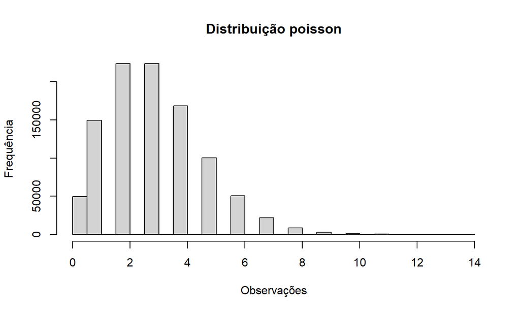

## Algumas distribuições

- **Binomial**: usada para dados com resposta mutuamente exclusiva, ou seja, sucesso ou fracasso (germinação de sementes, morte de insetos).

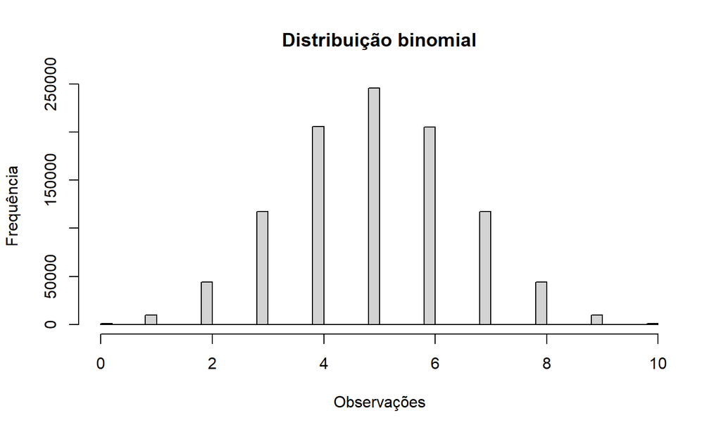

## Algumas distribuições

- **Gamma**: usada em dados contínuos e positivos (comprimento de raiz).

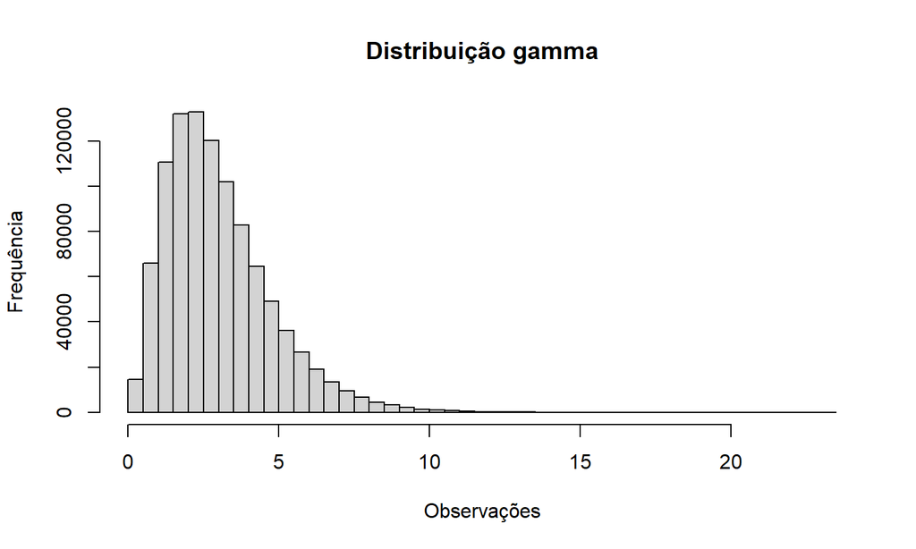

- **Outras distribuições:** https://en.wikipedia.org/wiki/Exponential_family

## Exemplo no R - GLM

Semelhante ao **lm()**, a função para criar o modelo é:

\[ glm(formula, family, data,...) \]

Em *family*, podemos ecolher a distribuição:**“binomial”**, **“poisson”**, **“gamma”**, entre outras.

A “ANOVA de um GLM” se chama Análise de Deviance e é usada a partir da mesma função **anova()**. Porém, devemos especificar o teste conforme a distribuição escolhida:

| Distribuição | Teste | Como fica |
| --- | --- | --- |
| Normal, gamma, | F | **anova(modelo, test=“F”)** |
| Binomial, poisson | \(\chi^2\) | **anova(modelo, test=“Chisq”)** |

## Exemplo no R - GLM Binomial

### \(1^{\circ}\) Carregando os dados

Experimento avaliando germinação de oito repetições de 25 sementes armazenadas por quatro meses em dois tipos de embalagem (0.1mm e 0.2mm).

```r
dados <- dget("https://raw.githubusercontent.com/thomasbrunomichelon/data/main/germinacao")
str(dados)
```

```
## 'data.frame':    64 obs. of  3 variables:
##  $ armazenamento: Factor w/ 4 levels "1","2","3","4": 1 1 1 1 1 1 1 1 1 1 ...
##  $ embalagem    : Factor w/ 2 levels "0.1","0.2": 1 1 1 1 1 1 1 1 2 2 ...
##  $ germ         : num  16 15 14 12 12 11 17 18 18 18 ...
```

## Exemplo no R - GLM Binomial

### \(2^{\circ}\) Criando a variável resposta

Criando uma nova variável com duas colunas, uma com a germinação e a outra com as sementes que não germinaram (25 sementes - o total germinado).

```r
resposta <- cbind(dados$germ, 25-dados$germ)
head(resposta)
```

```
##      [,1] [,2]
## [1,]   16    9
## [2,]   15   10
## [3,]   14   11
## [4,]   12   13
## [5,]   12   13
## [6,]   11   14
```

## Exemplo no R - GLM Binomial

### \(3^{\circ}\) Criando o modelo e realizando a análise de deviance

```r
modelo <- glm(resposta ~ armazenamento*embalagem, data=dados, family="binomial")
anova(modelo, test="Chisq")
```

```
## Analysis of Deviance Table
##
## Model: binomial, link: logit
##
## Response: resposta
##
## Terms added sequentially (first to last)
##
##
##                         Df Deviance Resid. Df Resid. Dev  Pr(>Chi)
## NULL                                       63    124.657
## armazenamento            3   31.330        60     93.327 7.242e-07 ***
## embalagem                1   18.272        59     75.054 1.915e-05 ***
## armazenamento:embalagem  3   10.646        56     64.408    0.0138 *
## ---
## Signif. codes:  0 '***' 0.001 '**' 0.01 '*' 0.05 '.' 0.1 ' ' 1
```

## Exemplo no R - GLM Binomial

### \(4^{\circ}\) Comparação de médias

```r
library(emmeans)
médias <- emmeans(modelo, specs=~armazenamento|embalagem, type="response")
library(multcomp)
cld(médias, Letters=LETTERS, reverse=TRUE)
```

```
## embalagem = 0.1:
##  armazenamento  prob     SE  df asymp.LCL asymp.UCL .group
##  2             0.595 0.0347 Inf     0.526     0.661  A
##  1             0.575 0.0350 Inf     0.505     0.642  A
##  3             0.490 0.0353 Inf     0.421     0.559  A
##  4             0.360 0.0339 Inf     0.296     0.429   B
##
## embalagem = 0.2:
##  armazenamento  prob     SE  df asymp.LCL asymp.UCL .group
##  1             0.710 0.0321 Inf     0.643     0.769  A
##  3             0.625 0.0342 Inf     0.556     0.689  AB
##  2             0.565 0.0351 Inf     0.495     0.632   B
##  4             0.540 0.0352 Inf     0.471     0.608   B
##
## Confidence level used: 0.95
## Intervals are back-transformed from the logit scale
## P value adjustment: tukey method for comparing a family of 4 estimates
## Tests are performed on the log odds ratio scale
## significance level used: alpha = 0.05
## NOTE: Compact letter displays can be misleading
##       because they show NON-findings rather than findings.
##       Consider using 'pairs()', 'pwpp()', or 'pwpm()' instead.
```

## Exemplo no R - GLM Poisson

### \(1^{\circ}\) Carregando os dados

Experimento avaliando o número de plântulas emergidas de três lotes de sementes, beneficiadas em peneiras com quatro crivos diferentes (testemunha, 0,84mm, 1mm, 1,18mm).

```r
dados <- dget("https://raw.githubusercontent.com/thomasbrunomichelon/data/main/contagem%20plantulas")
str(dados)
```

```
## 'data.frame':    48 obs. of  3 variables:
##  $ lote     : Factor w/ 3 levels "Lote 1","Lote 2",..: 1 1 1 1 2 2 2 2 3 3 ...
##  $ peneira  : Factor w/ 4 levels "0,84 mm","1 mm",..: 4 4 4 4 4 4 4 4 4 4 ...
##  $ plantulas: int  41 40 40 37 20 24 24 36 15 15 ...
```

### \(2^{\circ}\) Criando o modelo

```r
modelo <- glm(plantulas~lote*peneira, data=dados, family="poisson")
```

## Exemplo no R - GLM Poisson

### \(3^{\circ}\) Checando o pressuposto

```r
library(AER)
dispersiontest(modelo)
```

```
##
##  Overdispersion test
##
## data:  modelo
## z = -0.58628, p-value = 0.7212
## alternative hypothesis: true dispersion is greater than 1
## sample estimates:
## dispersion
##  0.8841533
```

## Exemplo no R - GLM Poisson

### \(4^{\circ}\) Análise de deviance

```r
anova(modelo, test="Chisq")
```

```
## Analysis of Deviance Table
##
## Model: poisson, link: log
##
## Response: plantulas
##
## Terms added sequentially (first to last)
##
##
##              Df Deviance Resid. Df Resid. Dev  Pr(>Chi)
## NULL                            47     888.10
## lote          2   240.80        45     647.30 < 2.2e-16 ***
## peneira       3   553.25        42      94.05 < 2.2e-16 ***
## lote:peneira  6    52.03        36      42.02 1.838e-09 ***
## ---
## Signif. codes:  0 '***' 0.001 '**' 0.01 '*' 0.05 '.' 0.1 ' ' 1
```

## Exemplo no R - GLM Poisson

### \(5^{\circ}\) Comparação de médias

```r
library(emmeans)
médias <- emmeans(modelo, specs=~peneira|lote, type="response")
library(multcomp)
cld(médias, Letters=LETTERS, reverse=TRUE)
```

```
## lote = Lote 1:
##  peneira     rate   SE  df asymp.LCL asymp.UCL .group
##  1,18 mm    92.00 4.80 Inf     83.06     101.9  A
##  1 mm       69.00 4.15 Inf     61.32      77.6   B
##  0,84 mm    41.25 3.21 Inf     35.41      48.0    C
##  Testemunha 39.50 3.14 Inf     33.80      46.2    C
##
## lote = Lote 2:
##  peneira     rate   SE  df asymp.LCL asymp.UCL .group
##  1,18 mm    96.50 4.91 Inf     87.34     106.6  A
##  1 mm       62.00 3.94 Inf     54.74      70.2   B
##  Testemunha 26.00 2.55 Inf     21.45      31.5    C
##  0,84 mm    18.25 2.14 Inf     14.51      23.0    C
##
## lote = Lote 3:
##  peneira     rate   SE  df asymp.LCL asymp.UCL .group
##  1,18 mm    52.25 3.61 Inf     45.63      59.8  A
##  1 mm       28.25 2.66 Inf     23.49      34.0   B
##  Testemunha 15.25 1.95 Inf     11.87      19.6    C
##  0,84 mm     7.75 1.39 Inf      5.45      11.0     D
##
## Confidence level used: 0.95
## Intervals are back-transformed from the log scale
## P value adjustment: tukey method for comparing a family of 4 estimates
## Tests are performed on the log scale
## significance level used: alpha = 0.05
## NOTE: Compact letter displays can be misleading
##       because they show NON-findings rather than findings.
##       Consider using 'pairs()', 'pwpp()', or 'pwpm()' instead.
```

## Comparação de modelos

## Critério de Akaike (AIC)

O AIC avalia duas coisas: o ajuste do modelo e o número de parâmetros. Quanto melhor o ajuste, melhor o modelo, porém, se o modelo precisou de muitos parâmetros para se ajustar, pior ele é.

\[ AIC=2k-2ln(L) \]

A fórmula do AIC é relativamente simples, nela contém uma parte relativa ao número de parâmetros (\(k\)) e outra parte relativa ao ajuste, por meio do valor máximo do chamado *likelihood* ou verossemilhança (\(L\)).

Reparem que de acordo com a fórmula, quanto mais parâmetros (parte positiva) e/ou quanto menor o ajuste (parte negativa), maior o valor de AIC. Logo, **quanto menor o valor de AIC melhor o modelo**.

## Exemplo no R - AIC

### \(1^{\circ}\) Carregando dados

Usaremos os dados do experimento referente ao número de plântulas emergidas.

```r
dados <- dget("https://raw.githubusercontent.com/thomasbrunomichelon/data/main/contagem%20plantulas")
str(dados)
```

```
## 'data.frame':    48 obs. of  3 variables:
##  $ lote     : Factor w/ 3 levels "Lote 1","Lote 2",..: 1 1 1 1 2 2 2 2 3 3 ...
##  $ peneira  : Factor w/ 4 levels "0,84 mm","1 mm",..: 4 4 4 4 4 4 4 4 4 4 ...
##  $ plantulas: int  41 40 40 37 20 24 24 36 15 15 ...
```

## Exemplo no R - AIC

### \(2^{\circ}\) Criando modelo normal e checando os pressupostos

```r
modelo_normal <- lm(plantulas~lote*peneira, data=dados)
erros <- residuals(modelo_normal)
shapiro.test(erros)
```

```
##
##  Shapiro-Wilk normality test
##
## data:  erros
## W = 0.9614, p-value = 0.115
```

```r
library(car)
leveneTest(erros~lote*peneira, data=dados)
```

```
## Levene's Test for Homogeneity of Variance (center = median)
##       Df F value Pr(>F)
## group 11  1.5016 0.1737
##       36
```

```r
durbinWatsonTest(modelo_normal)
```

```
##  lag Autocorrelation D-W Statistic p-value
##    1      -0.2310583       2.44401   0.972
##  Alternative hypothesis: rho != 0
```

## Exemplo no R - AIC

### \(3^{\circ}\) Criando modelo com distribuição de Poisson

```r
modelo_poisson <- glm(plantulas~lote*peneira, data=dados, family="poisson")
```

### \(4^{\circ}\) Criando modelo com distribuição binomial negativa

```r
library(MASS)
modelo_binomial_negativa <- glm.nb(plantulas~lote*peneira, data=dados)
```

## Exemplo no R - AIC

### \(5^{\circ}\) Comparando os modelos

\[ AIC(object,...) \]

```r
AIC(modelo_normal, modelo_poisson, modelo_binomial_negativa)
```

```
##                          df      AIC
## modelo_normal            13 331.9080
## modelo_poisson           12 326.0583
## modelo_binomial_negativa 13 328.0594
```

## O que realmente muda?

Se os dados são normais, por que testar outros ajustes?

```r
library(emmeans)
media_normal <- emmeans(modelo_normal, specs=~lote|peneira)
media_poisson <- emmeans(modelo_poisson, specs=~lote|peneira)
library(multcomp)
letras_normal <- cld(media_normal, Letters = LETTERS, reversed = T)
letras_poisson <- cld(media_poisson, Letters = LETTERS, reversed = T, type="response")
cbind(letras_normal, letras_poisson)[,c(1,2,8,16)]
```

```
##      lote    peneira .group .group.1
## 3  Lote 1    0,84 mm     A       A
## 2  Lote 2    0,84 mm      B       B
## 1  Lote 3    0,84 mm      B        C
## 6  Lote 1       1 mm     A        A
## 5  Lote 2       1 mm     A        A
## 4  Lote 3       1 mm      B        B
## 9  Lote 2    1,18 mm     A        A
## 7  Lote 1    1,18 mm     A        A
## 8  Lote 3    1,18 mm      B        B
## 12 Lote 1 Testemunha     A       A
## 11 Lote 2 Testemunha      B       B
## 10 Lote 3 Testemunha      B        C
```

## Referências

- Bussab, W. O.; MORETTIN, P. A. Estatística Básica (9 ed.). Saraiva, 2017, p. 553.
- Pimentel Gomes, F. Curso de Estatística Experimental (12 ed.). Piracicaba, 1987, p. 467.
- Cordeiro, G. M.; Demétrio, C. G. Modelos lineares generalizados e extensões. Piracicaba, 2008, p. 400.
- http://leg.ufpr.br/~walmes/mpaer/index.html
- https://tiagoolivoto.github.io/e-bookr/index.html